# Exploring one day

## Extending the elevation model

Examining the PC of the residuals, seems clear to incorporate aspect effects and individual location station levels $f_i(t) = \mu(t) + \alpha_i + Elev_i \beta(t) + AspectN_i \delta(t) + \epsilon_i(t)$ where $AspectN_i$ is an indicator variable taking the value 1 when station $i$ predominantly faces North.

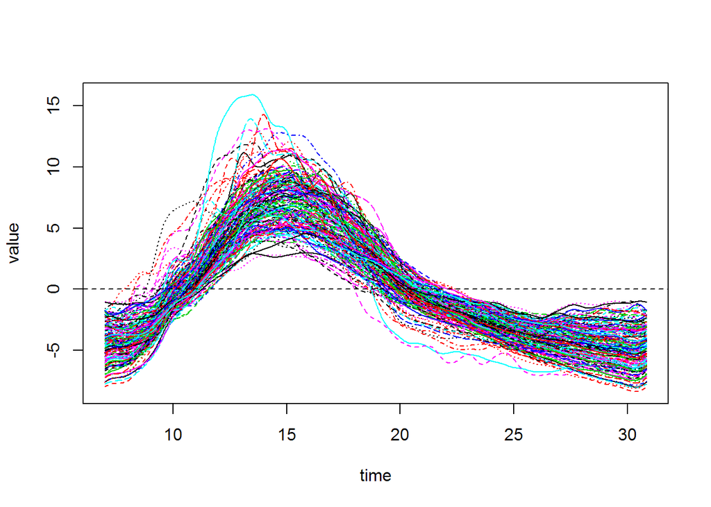

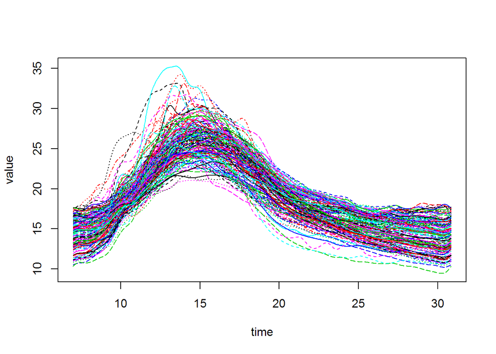

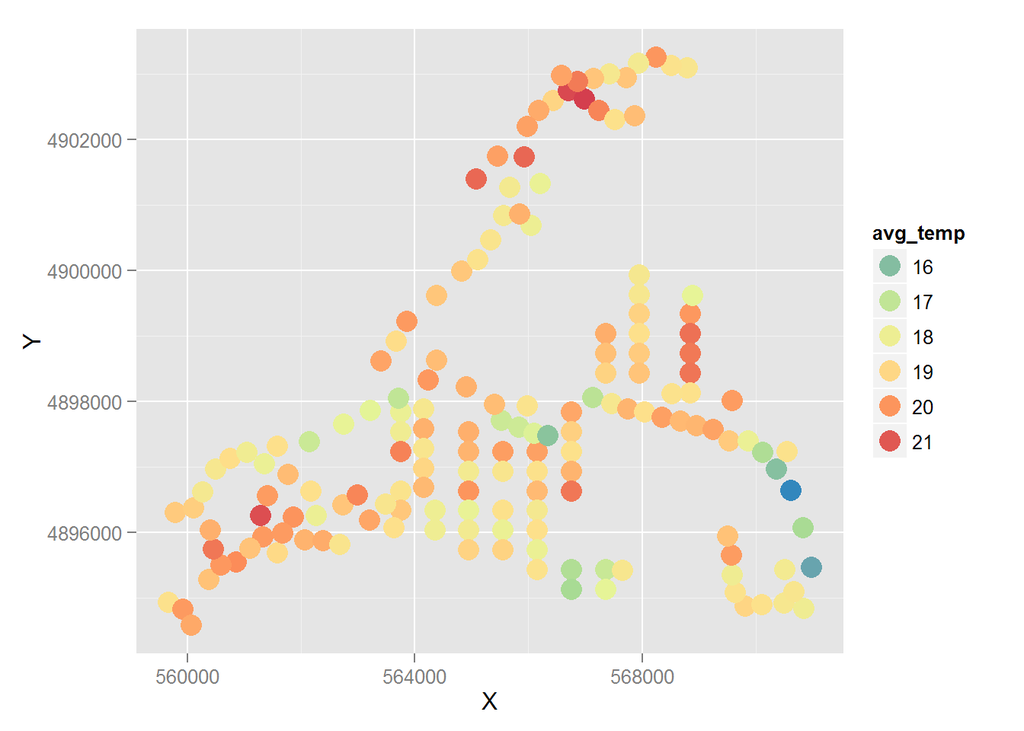

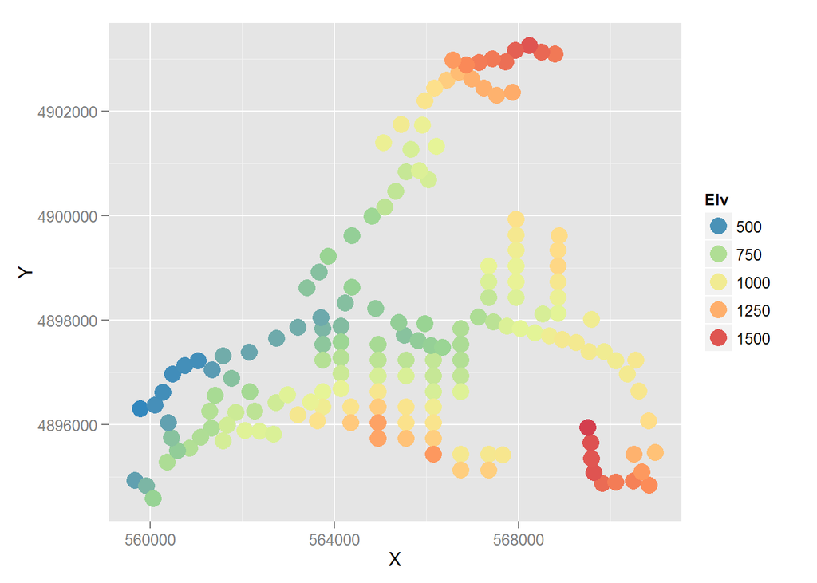

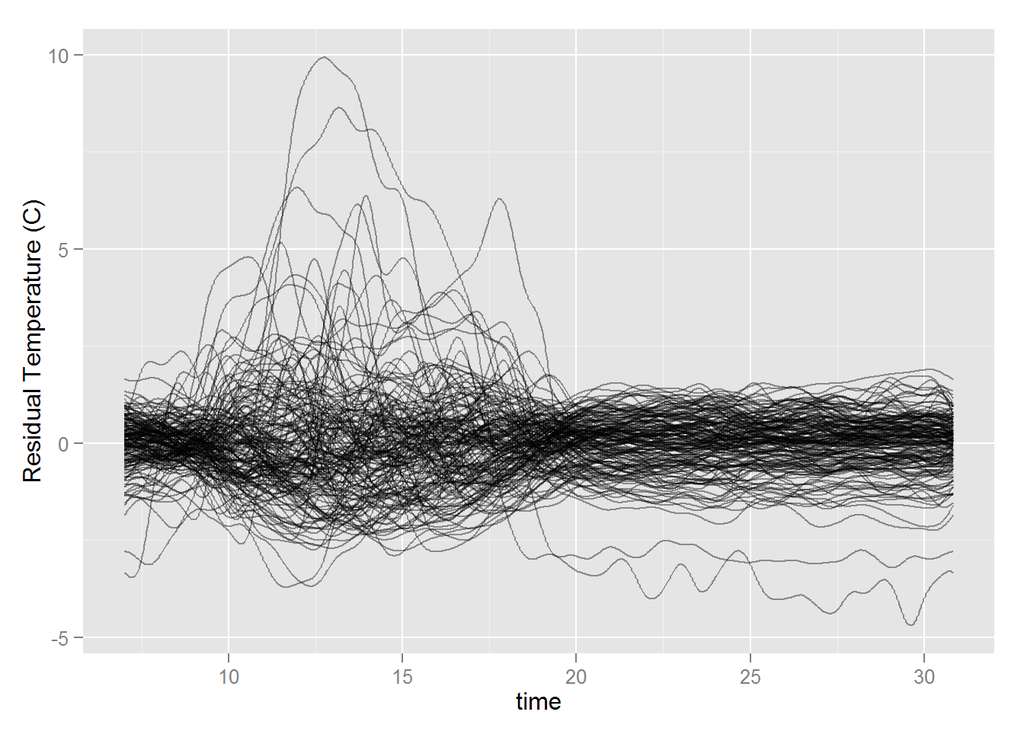

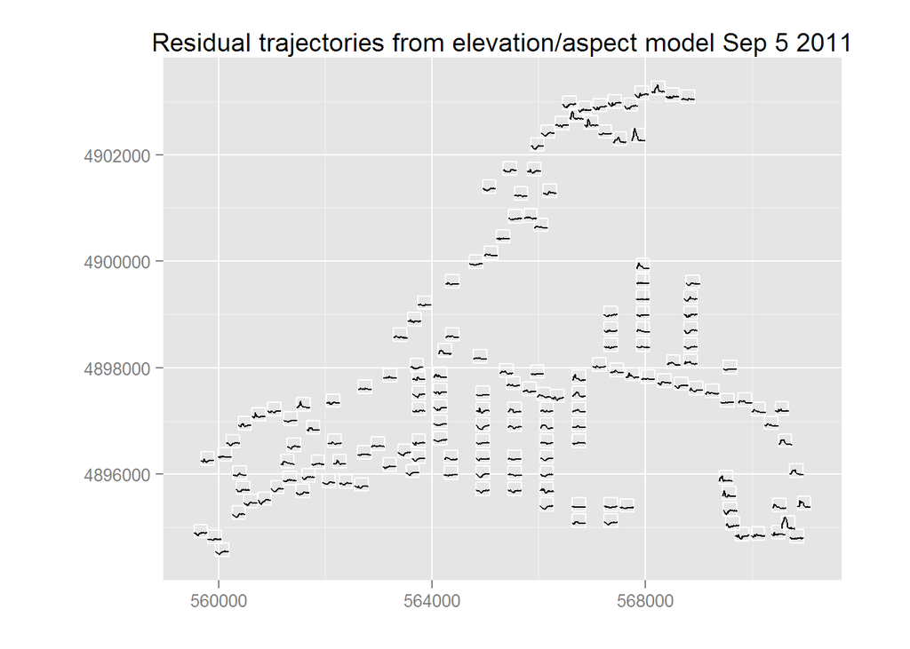

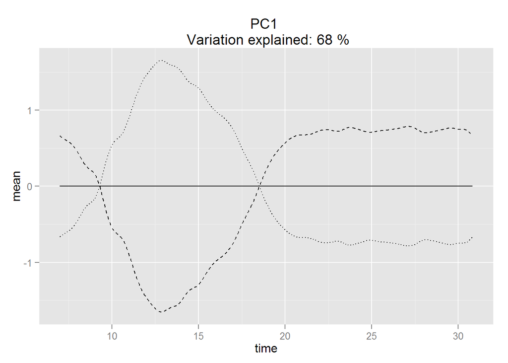

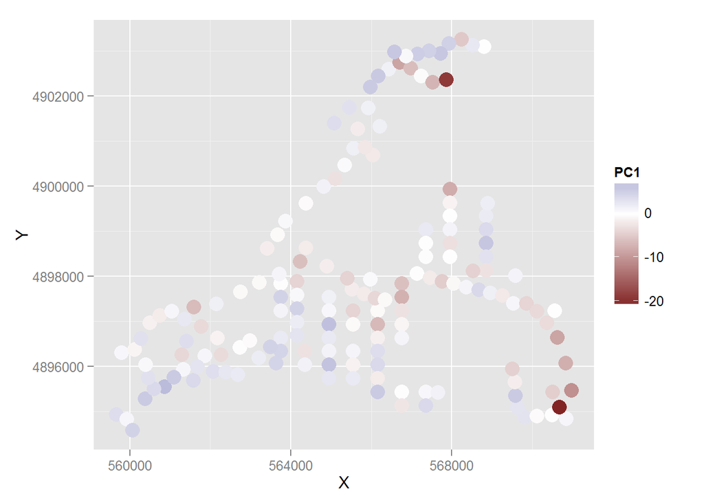

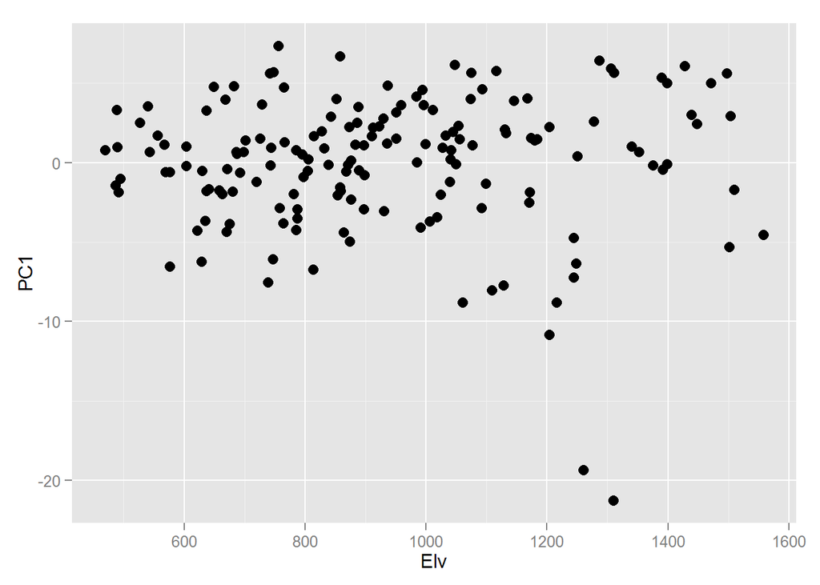

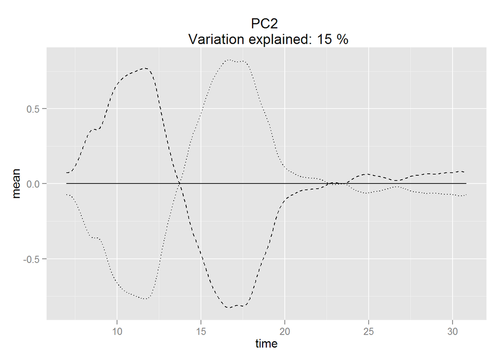

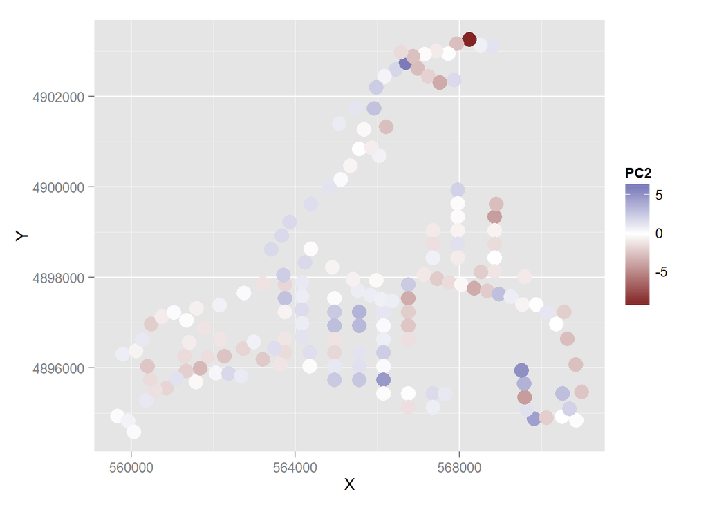

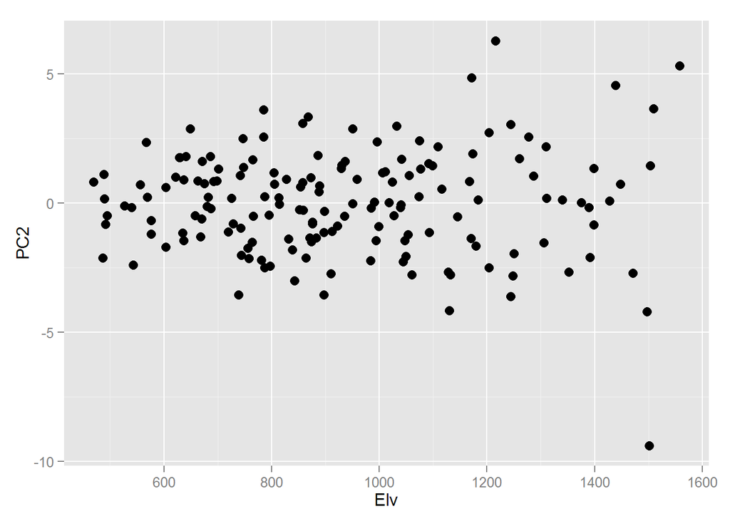

[9 more figures not shown]

Additional thoughts:

- Does additive versus multiplicative make sense?
- How about repeating this on the derivatives?
- Location (x, y) and elevation (z) are describing a  
  2d surface, so any modelled effects of elevation or location can’t really be pulled apart. I.e. the elevation model is probably capturing some location effects too. Probably also some vegetation effects.